# Tugas M3_Fabyan Riza Kiram_164221068

Fabyan Riza Kiram

2023-09-19

## Mengambil dataset dari sebuah file dan mendeklarasikan beberapa variabel

```r
df = read.csv("concrete_data.csv")

semen = df$Cement
ampas = df$Blast.Furnace.Slag
abu = df$Fly.Ash
air = df$Water
kekakuan = df$Superplasticizer
sifat_kasar = df$Coarse.Aggregate
kehalusan = df$Fine.Aggregate
umur = df$Age
kekuatan = df$Strength
```

# Menggunakan fungsi library ggplot

## **Scatter Plot**

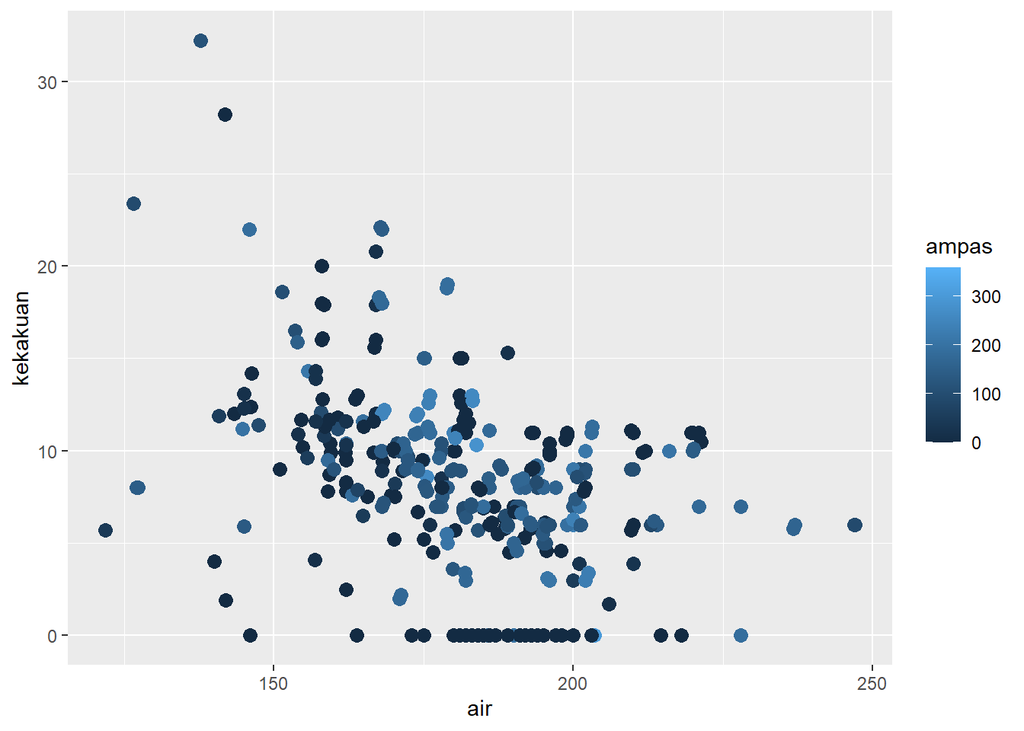

```r
library(ggplot2)
qplot(air, kekakuan, data = df, colour=ampas) + geom_point(size=3)
```

## Interpretasi

Pada visualisasi diatas, dapat dilihat bahwa terdapat korelasi di antara jumlah air yang terkandung di dalam semen dan juga kekakuan semen tersebut. Hubungan yang ada merupakan korelasi negatif, maka makin banyak air, makin kecil kekakuan dari semen (makin tidak kaku) dan juga sebaliknya. Dapat dilihat juga terdapat pola bahwa jumlah ampas semen akan sedikit jika semen hanya mengandung salah satu variabel yang tertera di atas (jumlah air banyak tanpa ada nilai kekakuan / nilai kekakuan yang tinggi dengan jumlah air yang sedikit)

## **Box Plot**

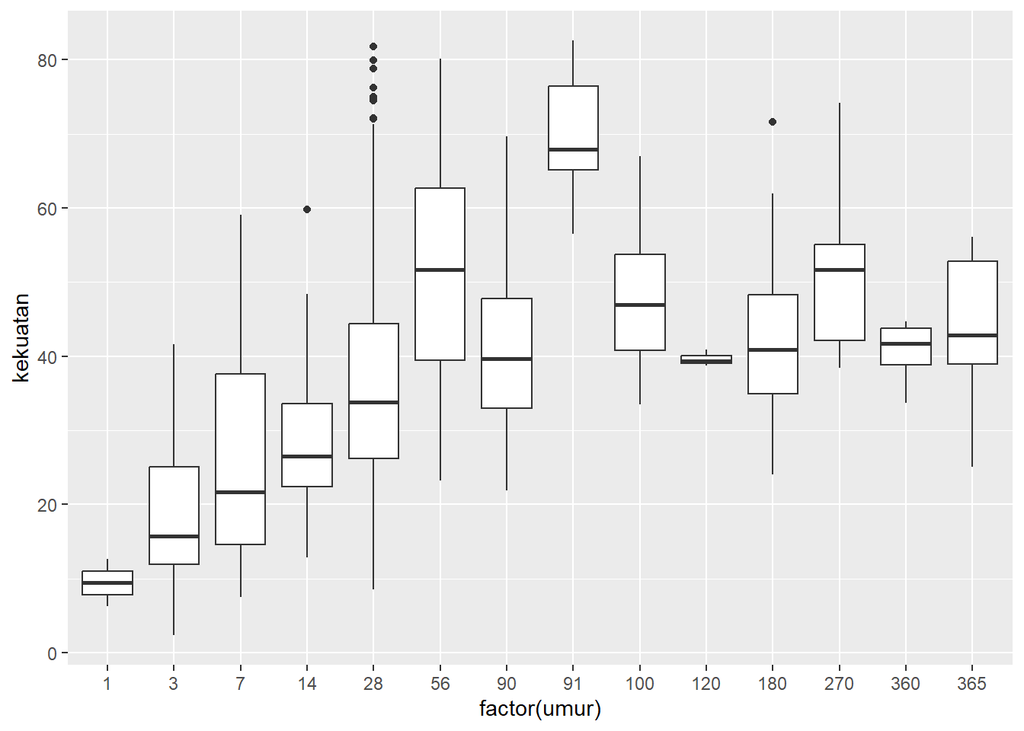

```r
qplot(factor(umur), kekuatan, data = df, geom = ("boxplot"))
```

## **Density Plot**

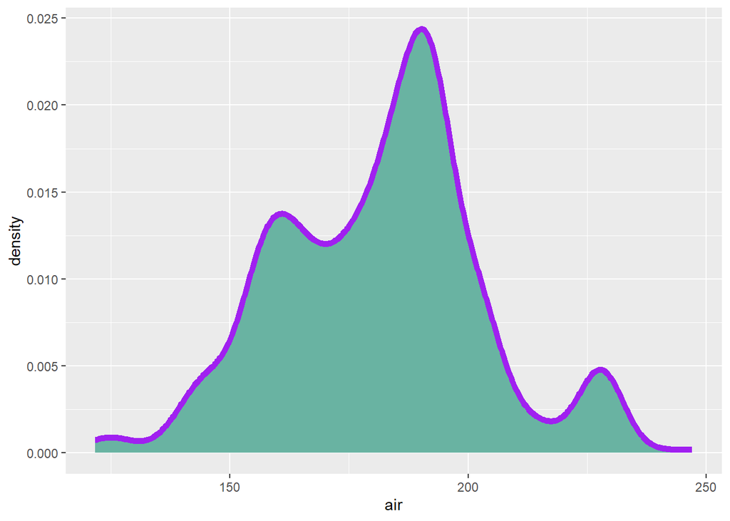

```r
ggplot(df, aes(x=air)) +
  geom_density(
    color="purple",
    fill="#69b3a2",
    size = 2
  )
```

## Interpretasi

Visualisasi diatas menunjukkan berapa jumlah kandungan air yang sering digunakan menggunakan density plot. Dapat dilihat bahwa dalam pembuatan semen, banyaknya kandungan air yang digunakan ada pada rentang 200 L

# Menggunakan fungsi bawaan R

## **Histogram**

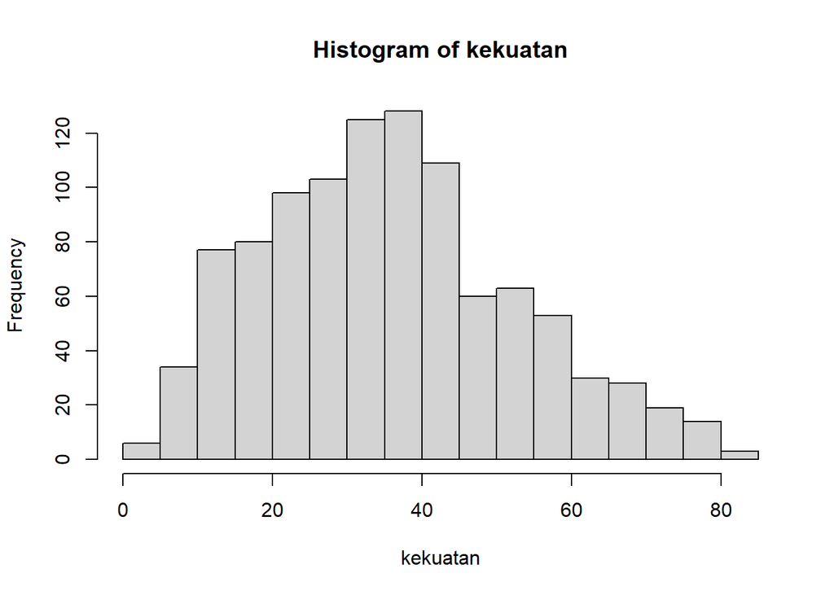

```r
hist(kekuatan)
```

## Interpretasi

Visualisasi diatas merupakan histogram, dimana variabel yang digunakan adalah nilai ‘kekuatan’ dari semen. Histogram berfungsi untuk memberikan distribusi dari variabel yang telah ditentukan. Dapat dilihat bahwa persebaran kekuatan semen menyerupai distribusi normal meskipun terdapat kemiringan (skewness) di bagian kanan.

## **Scatter Plot**

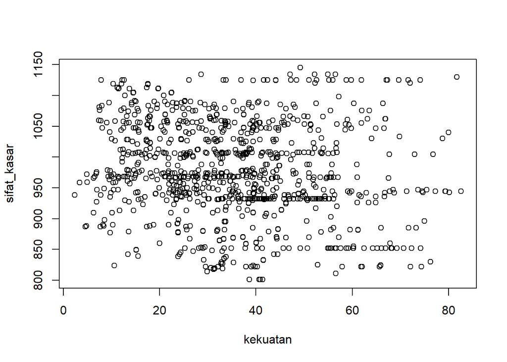

```r
plot(kekuatan,sifat_kasar)
```

## Interpretasi

Dalam visualisasi di atas (scatter plot) dapat dilihat bahwa tidak ada korelasi khusus di antara kekuatan semen dan sifat kasar dari semen tersebut. Artinya kekuatan (variabel independen) tidak mempengaruhi nilai dari sifat kekasaran semen (variabel dependen)